# Tropicalization in the Wadden Sea

Lucie Kuczynski

2025-02-11

# Introduction

This tutorial explains how to analyze tropicalization in marine communities using three scripts that work together to:

1. Extract temperature data for species occurrences
2. Calculate Species Temperature Index (STI)
3. Analyze Community Temperature Index (CTI) and assess tropicalization processes

# 📋 Prerequisites

Before starting, ensure you have:

- R version 4.0.0 or higher
- Required R packages (automatically installed in setup)
- Your community data in wide format (species as columns)
- Access to temperature data (MODIS SST rasters)

# 🗂️ Directory Structure

⚠️ **Important**: Your directory structure should look like this:

```
your_main_folder/
|-- analysis
|   |-- compute_CTI.R
|   |-- compute_STI.R
|   `-- extract_temperatures.R
`-- data
    |-- mzb_wide.csv
    |-- ...
    `-- ppkt_wide.csv

temperatures_folder/
`-- data
    |-- processed
    |   |-- AquaMODIS
    |   |   |-- TERRA_MODIS.20000301_20000331.L3m.MO.SST.sst.4km_sst.tif
    |   |   |-- TERRA_MODIS.20000401_20000430.L3m.MO.SST.sst.4km_sst.tif
    |   |   |-- ...
    |   |   `-- TERRA_MODIS.20241101_20241130.L3m.MO.SST.sst.4km_sst.tif
    |   `-- average_sst.tif
    `-- raw
        `-- AquaMODIS
            |-- TERRA_MODIS.20000301_20000331.L3m.MO.SST.sst.4km.nc
            |-- TERRA_MODIS.20000401_20000430.L3m.MO.SST.sst.4km.nc
            |-- ...
            `-- TERRA_MODIS.20241101_20241130.L3m.MO.SST.sst.4km.nc
```

⚠️ **Note**: The temperature data can be in a different folder, but make sure to update paths accordingly.

# Step 1: Extract Temperature Data

## 🎯 Goal

Extract temperature values for each species occurrence from MODIS SST raster data.

## Setup - critical 🚨

1. Prepare your community data CSV with these **required columns**:
- SampleID
- StationID
- year
- lat (latitude)
- long (longitude)
- Species abundance columns
2. Set up file paths:

```r
data_name <- "mzb" # MODIFY THE NAME OF THE DATASET

base_dir <- "/Users/lucie/Dropbox/Wadden_Tropicalization" # MODIFY THIS PATH
input_dir <- file.path(base_dir, "data")
output_dir <- file.path(base_dir, "output")
modis_dir <- file.path("/Users/lucie/Documents/Work/Academia/Data/TerraModis/data/processed/AquaMODIS")  # MODIFY THIS PATH

if(!dir.exists(output_dir)) dir.create(output_dir, recursive = TRUE)

community_file <- file.path(input_dir, paste0(data_name, "_wide.csv")) # UPDATE THE PATH TO YOUR COMMUNITY DATA IF NEEDED
avg_sst_file <- file.path("/Users/lucie/Documents/Work/Academia/Data/TerraModis/data/processed/average_sst.tif")  # MODIFY THIS PATH
temperature_output <- file.path(output_dir, paste0(data_name, "_temperatures.csv"))
sti_output <- file.path(output_dir, paste0(data_name, "_STI.csv"))

# Import the community data
community <- read.csv(file.path(community_file), stringsAsFactors = FALSE)[, -1]
# Identify non-species columns (adjust based on your data structure)
info_cols <- which(colnames(community) %in%
                     c("SampleID", "StationID", "year", "lat", "long"))
# Determine the range of years needed for temperature extraction
year_range <- range(community$year, na.rm = TRUE)
```

⚠️ **Warning**: The most common errors come from incorrect file paths. Double-check your paths!

## Code

```r
source("extract_temperatures.R")

# Call the temperature extraction function. It outputs a CSV with updated temperature
# information for each community record.
updated_community <- extract_temperature_for_communities(
  community = community,
  data_dir = modis_dir,
  avg_file = avg_sst_file,
  output_csv = temperature_output,
  year_range = year_range,
  show_progress = FALSE
)
```

## Expected Output

The function adds two columns to your community data:

- `temperature`: The extracted SST value
- `actual`: Character indicating if it’s actual yearly data, monthly data or average based on all temperature data available

Example of temperature-updated community data

|  | SampleID | StationID | year | lat | long | temperature | actual |
| --- | --- | --- | --- | --- | --- | --- | --- |
| 986 | WuKu_MZB_6_2014 | WuKu_MZB_6 | 2014 | 53.80332 | 8.527664 | 12.63792 | yearly |
| 987 | WuKu_MZB_6_2015 | WuKu_MZB_6 | 2015 | 53.80332 | 8.527664 | 11.53333 | yearly |
| 988 | WuKu_MZB_6_2016 | WuKu_MZB_6 | 2016 | 53.80332 | 8.527664 | 11.29727 | yearly |
| 989 | WuKu_MZB_6_2017 | WuKu_MZB_6 | 2017 | 53.80332 | 8.527664 | 10.98667 | yearly |
| 990 | WuKu_MZB_6_2018 | WuKu_MZB_6 | 2018 | 53.80332 | 8.527664 | 11.97708 | yearly |
| 991 | WuKu_MZB_6_2019 | WuKu_MZB_6 | 2019 | 53.80332 | 8.527664 | 11.62958 | yearly |

# Step 2: Calculate Species Temperature Index (STI)

## 🎯 Goal

Calculate the average temperature experienced by each species across all its occurrences.

## Code

```r
source("compute_STI.R")

sti_results <- compute_STI(
  data_name = data_name,
  input_dir = input_dir,
  output_dir = output_dir,
  show_progress = FALSE
)
```

⚠️ **Important**: The script expects specific column names. Make sure your data matches the requirements listed in Step 1.

## Expected Output

The function creates a CSV file with:

- species: Species name
- STI: Mean temperature experienced
- n_occ: Number of occurrences used

Example of STI results

| species | STI | n_occ |
| --- | --- | --- |
| Abludomelita.obtusata | 11.76458 | 1 |
| Abra | 10.59458 | 1 |
| Abra.alba | 10.95528 | 29 |
| Abra.nitida | 11.14365 | 4 |
| Abra.prismatica | 11.10417 | 2 |
| Abra.tenuis | 11.07510 | 3 |

# Step 3: Analyze Community Temperature Index (CTI)

## 🎯 Goal

Calculate community-level temperature indices and analyze tropicalization processes.

## Code

```r
# Load the functions
source("compute_CTI.R")

# Calculate CTI
observed_CTI <- get_CTI(
  community_matrix = community,
  STI = sti_results,
  infos_col = info_cols,  # columns for SampleID, Station, Year, etc.
  occu = TRUE       # presence/absence (TRUE) or abundance-based (FALSE)
)
```

## Visualize Results

### Plot CTI trend

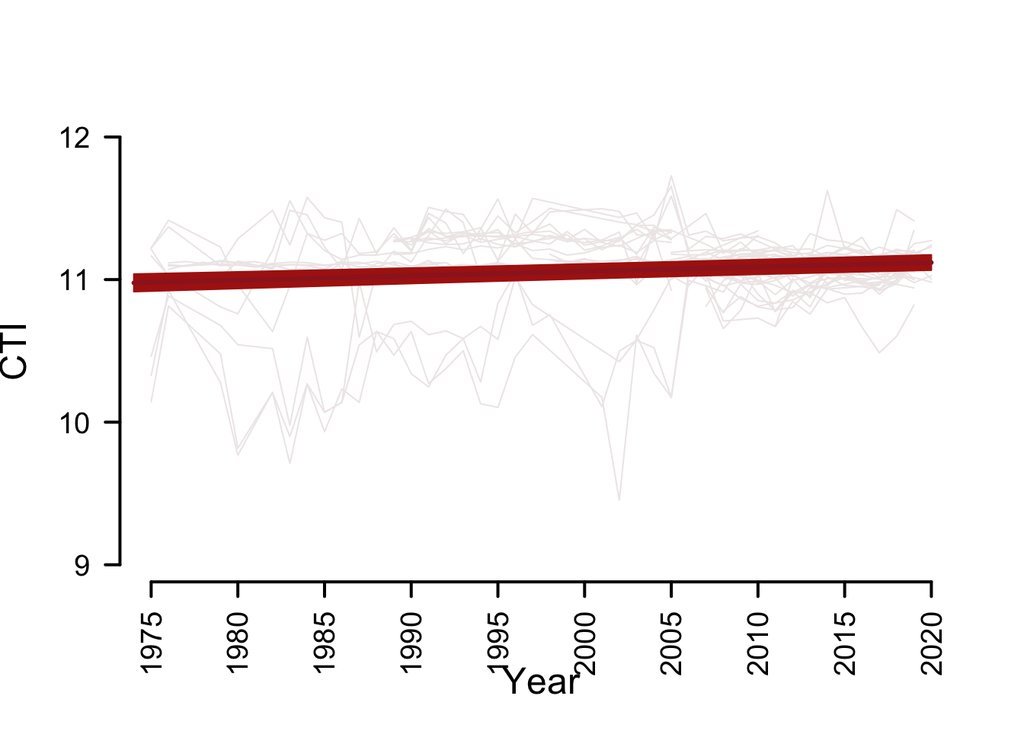

```
## Linear mixed-effects model fit by REML
##   Data: CTI
##         AIC       BIC   logLik
##   -944.0709 -924.4841 476.0354
##
## Random effects:
##  Formula: ~1 | station
##         (Intercept)  Residual
## StdDev:     0.18562 0.1355145
##
## Fixed effects:  cti ~ year
##                Value Std.Error  DF  t-value p-value
## (Intercept) 4.862759 1.0594472 939 4.589902       0
## year        0.003097 0.0005279 939 5.867745       0
##  Correlation:
##      (Intr)
## year -1
##
## Standardized Within-Group Residuals:
##         Min          Q1         Med          Q3         Max
## -7.49568723 -0.25925927  0.02178418  0.29899903  5.04028898
##
## Number of Observations: 991
## Number of Groups: 51
##             R2m       R2c
## [1,] 0.02398971 0.6606594
```

```r
plot_trend(observed_CTI)
```

**Explanation of the plot:**

- Blue trend: No significant temporal change in community temperature
- Red trend: Significant trend
- Shaded area: 95% confidence interval
- Individual gray lines: Station-specific trends

### Analyze tropicalization processes

```r
inferred_processes <- get_processes(
  community_matrix = community,
  STI = sti_results,
  CTI = observed_CTI,
  infos_col = info_cols,
  all_outputs = TRUE,
  log = TRUE
)
```

Species-level trends

| Station | species | estimate | pvalue | trend | STI | n_occ | difference | process |
| --- | --- | --- | --- | --- | --- | --- | --- | --- |
| 1 | Abra.tenuis | 0.0569564 | 0.1935912 | increase | 11.07510 | 3 | -0.1194510 | borealisation |
| 1 | Alitta.succinea | 0.0621293 | 0.4101780 | increase | 10.92836 | 165 | -0.2661881 | borealisation |
| 1 | Alitta.virens | -0.0166164 | 0.3739394 | decrease | 11.13898 | 40 | -0.0555699 | detropicalisation |
| 1 | Aphelochaeta.marioni | 0.1097006 | 0.3833019 | increase | 11.14002 | 31 | -0.0545343 | borealisation |
| 1 | Arenicola.marina | 0.0751203 | 0.2192845 | increase | 11.00539 | 283 | -0.1891577 | borealisation |
| 1 | Capitella.capitata | 0.1142402 | 0.1000783 | increase | 10.87024 | 308 | -0.3243147 | borealisation |

Process strength (%) by station

| Station | process | strength |
| --- | --- | --- |
| 1 | borealisation | 49.1 |
| 1 | deborealisation | 26.0 |
| 1 | detropicalisation | 7.2 |
| 1 | tropicalisation | 17.7 |
| 10 | borealisation | 26.4 |
| 10 | deborealisation | 7.8 |

### Visualize species trends

[figure not shown]

```r
plot_species(inferred_processes$trends)
```

In the species plot:

- Point size indicates magnitude of STI difference from community average
- Colors indicate different processes
- Position shows relationship between species’ thermal preference (STI) and population trend

# 🆘 Troubleshooting

## Common Issues and Solutions

1. **File Not Found Errors**
- Verify all file paths are correct
- Use `file.path()` instead of string concatenation
- Check file permissions
2. **Missing Columns**
- Ensure column names match exactly (case-sensitive)
- Remove any hidden characters in column names
- Use `colnames()` to verify column names
3. **Data Format Issues**
- Check data types: `str(community)`
- Look for NA values: `colSums(is.na(community))`
- Verify numeric columns: `sapply(community, class)`
4. **Memory Issues**
- Close other R sessions
- Use `gc()` to free memory
- Consider processing data in chunks

## 🛟 Getting Help

If you encounter issues:

1. Check the error message carefully
2. Verify your data structure matches requirements
3. Test with a smaller subset of data
4. Contact us by email:
- A minimal reproducible example
- Your R session info: `sessionInfo()`
- Error messages